# Advanced models

# 1 Getting started

This notebook pairs the R examples with Python code and output. The language tabs are synchronized throughout the document. Both languages use the saved data in the accompanying `data` folder. The original download examples remain available but are not run during rendering. Fitting routines and random initialization can produce different results between languages.

## 1.1 Required packages

Quarto uses knitr and reticulate; install reticulate 1.41 or later. The loading chunk declares the Python dependencies for reticulate’s managed environment. The neural network examples use Keras 2.15 and TensorFlow 2.15, matching the R `keras` interface. For an existing Python environment, install `numpy<2`, pandas, scipy, matplotlib, seaborn, statsmodels, requests, yfinance, plotly, arch, `keras==2.15.*`, and `tensorflow==2.15.*`. Select that environment with `RETICULATE_PYTHON` before rendering if needed. Render with `quarto render 4_advanced_models_R_Python.qmd`. Training the networks takes longer than the statistical examples.

**R**

```r
Sys.setenv(TF_CPP_MIN_LOG_LEVEL = "2", TF_NUM_INTRAOP_THREADS = "2",
           TF_NUM_INTEROP_THREADS = "2")
reticulate::py_require(c("numpy<2", "pandas", "scipy", "matplotlib", "seaborn",
                         "statsmodels", "requests", "yfinance", "plotly", "arch",
                         "keras==2.15.*", "tensorflow==2.15.*"),
                       python_version = ">=3.10,<3.12")
library(highcharter) # For interactive plots
library(WDI)         # For World Bank data
library(RcppRoll)    # Rolling function fast with C++
library(openxlsx)    # A cool package to deal with Excel files/formats
library(quantmod)    # Package for financial data extraction
library(tsibble)     # TS with dataframes framework
library(fable)       # Package for time-series models & predictions
library(feasts)      # Package for time-series analysis
library(forecast)    # Another package for TS (forecasting)
library(tseries)     # Simple package for time-series tests
library(plotly)      # For 3D graphs
library(mvtnorm)     # For multivariate Gaussian distributions
library(crypto2)     # For cryto data
library(ggsci)       # For color palettes
library(rugarch)     # For GARCH models
library(fGarch)      # For GARCH models
library(keras)       # For neural networks
library(vars)        # For VAR (Vector AutoRegressive) models
library(tidyverse)   # THE library for data science; at the end to override other functions
set.seed(42)         # Random seed

impute <- function(v, n = 6){     # Imputation function
  for(j in 1:n){
    ind <- which(is.na(v))
    if(length(ind)>0){
      if(ind[1]==1){ind <- ind[-1]}
      v[ind] <- v[ind-1]
    }
  }
  return(v)
}
```

**Python**

```python
import os
os.environ.setdefault("TF_CPP_MIN_LOG_LEVEL", "2")
```

```
'2'
```

```python
os.environ.setdefault("TF_NUM_INTRAOP_THREADS", "2")
```

```
'2'
```

```python
os.environ.setdefault("TF_NUM_INTEROP_THREADS", "2")
```

```
'2'
```

```python
import numpy as np
import pandas as pd
import matplotlib.pyplot as plt
import seaborn as sns
import requests
import yfinance as yf
import plotly.express as px
from scipy.stats import norm
from statsmodels.tsa.stattools import acf
from statsmodels.tsa.api import VAR
from statsmodels.tsa.arima.model import ARIMA
from arch import arch_model
from arch.univariate import ConstantMean, GARCH, Normal
from tensorflow import keras

rng = np.random.default_rng(42)
sns.set_theme(style="whitegrid")

def impute(values, n=6):
    return values.ffill(limit=n)
```

## 1.2 Fetching some (crypto) data

The download snippets show CoinMarketCap through R’s `crypto2` and Yahoo Finance through Python’s `yfinance`. They are optional; the calculations below use the same saved prices in both languages.

**R**

```r
coins <- crypto_list()
c_info <- crypto_info(coin_list = coins, limit = 30)
coin_names <- c("Bitcoin", "Ethereum", "Tether USDt", "BNB", "USDC", "Solana")
coin_hist <- crypto_history(coins |> dplyr::filter(name %in% coin_names),
                            start_date = "20170101",
                            end_date = "20251206")
coin_hist <- coin_hist |>  # Timestamps are at midnight, hence we add a day.
  dplyr::mutate(date = 1 + as.Date(as.POSIXct(timestamp, origin="1970-01-01")))
coin_hist <- coin_hist |>
  group_by(name) |>
  mutate(return = close / lag(close) - 1 ) |>
  ungroup()
```

**Python**

```python
coin_tickers = {"BTC-USD": ("bitcoin", "Bitcoin", "BTC"),
                "ETH-USD": ("ethereum", "Ethereum", "ETH"),
                "USDT-USD": ("tether", "Tether USDt", "USDT"),
                "BNB-USD": ("bnb", "BNB", "BNB"),
                "USDC-USD": ("usd-coin", "USDC", "USDC"),
                "SOL-USD": ("solana", "Solana", "SOL")}
quotes = yf.download(list(coin_tickers), start="2017-01-01", end="2025-12-07",
                     auto_adjust=False, progress=False)
closes = quotes["Close"].reindex(columns=list(coin_tickers))
closes.index.name = "date"
coin_hist = (closes.reset_index().melt(id_vars="date", var_name="ticker", value_name="close")
             .dropna(subset=["close"]))
for column, position in [("slug", 0), ("name", 1), ("symbol", 2)]:
    coin_hist[column] = coin_hist["ticker"].map(lambda ticker: coin_tickers[ticker][position])
coin_hist = coin_hist.sort_values(["name", "date"])
coin_hist["return"] = coin_hist.groupby("name")["close"].pct_change(fill_method=None)
```

The worked examples use the saved CoinMarketCap sample from the original notebook, through November 29, 2025. Identical duplicate prices have been removed, and dates identify the closing day.

**R**

```r
coin_hist <- read_csv("data/4_advanced_models_crypto_prices.csv",
                      col_types = cols(timestamp = col_date(), date = col_date())) |>
  arrange(name, date) |> group_by(name) |>
  mutate(return = close / lag(close) - 1) |> ungroup()
head(coin_hist)
```

```
# A tibble: 6 × 7
  timestamp  date       slug  name  symbol close   return
  <date>     <date>     <chr> <chr> <chr>  <dbl>    <dbl>
1 2017-07-25 2017-07-25 bnb   BNB   BNB    0.106 NA
2 2017-07-26 2017-07-26 bnb   BNB   BNB    0.105 -0.00691
3 2017-07-27 2017-07-27 bnb   BNB   BNB    0.108  0.0247
4 2017-07-28 2017-07-28 bnb   BNB   BNB    0.104 -0.0341
5 2017-07-29 2017-07-29 bnb   BNB   BNB    0.108  0.0360
6 2017-07-30 2017-07-30 bnb   BNB   BNB    0.106 -0.0130
```

**Python**

```python
coin_hist = pd.read_csv("data/4_advanced_models_crypto_prices.csv",
                        parse_dates=["timestamp", "date"])
coin_hist = coin_hist.sort_values(["name", "date"])
coin_hist["return"] = coin_hist.groupby("name")["close"].pct_change(fill_method=None)
print(coin_hist.head())
```

```
      timestamp       date slug name symbol     close    return
3255 2017-07-25 2017-07-25  bnb  BNB    BNB  0.105870       NaN
3256 2017-07-26 2017-07-26  bnb  BNB    BNB  0.105138 -0.006914
3257 2017-07-27 2017-07-27  bnb  BNB    BNB  0.107737  0.024720
3258 2017-07-28 2017-07-28  bnb  BNB    BNB  0.104067 -0.034064
3259 2017-07-29 2017-07-29  bnb  BNB    BNB  0.107811  0.035977
```

# 2 ARCH-type models

## 2.1 Realized volatility

Then, let’s have a look at volatility. It’s measured as

$$v_t=\sqrt{\frac{1}{T-1}\sum_{s=0}^{T-1}(r_{t-s}-\bar{r}_t)^2},$$
where $\bar{r}_t$ is the mean return in the window of $T$ observations. Below, we compute the rolling standard deviation over 20 days. Each window ends on the date shown.

**R**

```r
coin_hist <- coin_hist |>
  arrange(name, date) |>
  group_by(name) |>
  filter(!is.na(return)) |>
  mutate(real_vol_20 = RcppRoll::roll_sd(return, n = 20, fill = NA, align = "right")) |>
  ungroup()
```

**Python**

```python
coin_hist = coin_hist.dropna(subset=["return"]).sort_values(["name", "date"]).copy()
coin_hist["real_vol_20"] = coin_hist.groupby("name")["return"].transform(
    lambda values: values.rolling(20).std(ddof=1))
```

**R**

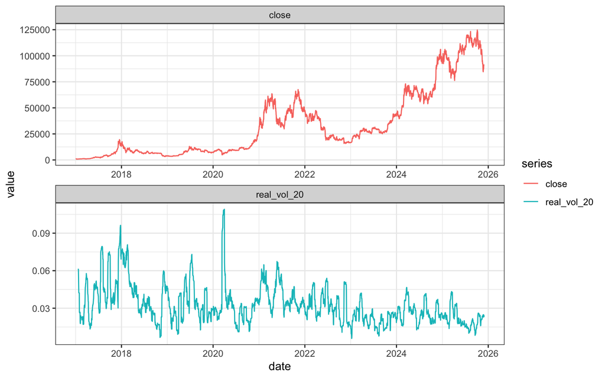

```r
coin_hist |>
  filter(name == "Bitcoin") |>
  pivot_longer(all_of(c("close", "real_vol_20")), names_to = "series", values_to = "value") |>
  ggplot(aes(x = date, y = value, color = series)) + geom_line() + theme_bw() +
  facet_wrap(vars(series), nrow = 2, scales = "free")# + scale_y_log10()
```

**Python**

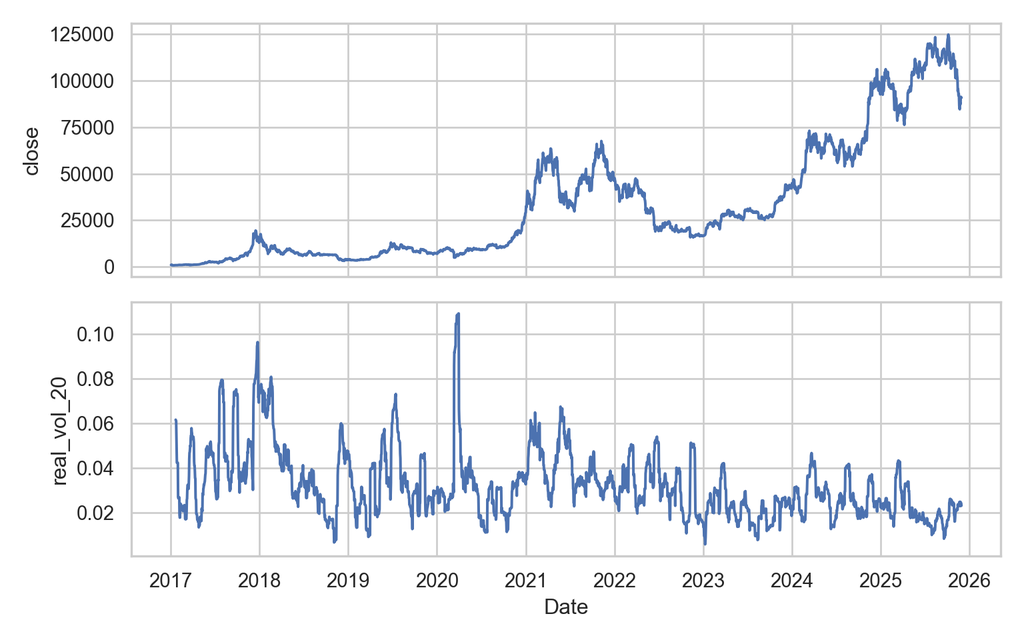

```python
btc_volatility = coin_hist.loc[coin_hist["name"].eq("Bitcoin")]
fig, axes = plt.subplots(2, 1, figsize=(8, 5), sharex=True)
for ax, column in zip(axes, ["close", "real_vol_20"]):
    ax.plot(btc_volatility["date"], btc_volatility[column])
    ax.set_ylabel(column)
axes[1].set_xlabel("Date")
fig.tight_layout()
plt.show()
```

Now let’s have a look a the autocorrelation of the volatility: it’s highly persistent.

**R**

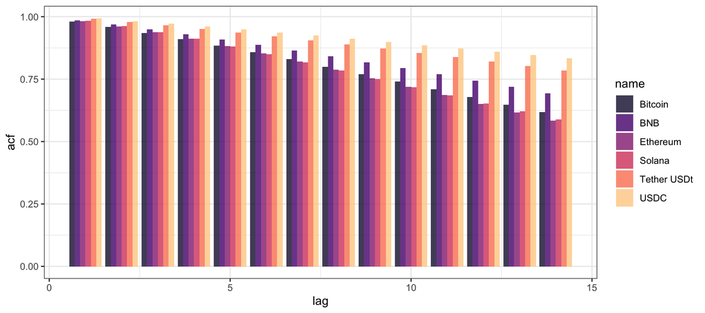

```r
crypto_acf <- coin_hist |>
  na.omit() %>%
  split(.$name) %>%
  map(~acf(.$real_vol_20, plot = F)) %>%
  map_dfr(
    ~data.frame(lag = .$lag,
                acf = .$acf,
                ci = qnorm(0.975)/sqrt(.$n.used)
    ), .id = "name")
crypto_acf |>
  filter(lag > 0, lag < 15) |>
  ggplot(aes(x = lag, y = acf, fill = name)) +
  geom_col(position = "dodge", alpha = 0.8) + theme_bw() +
  scale_fill_viridis_d(option = "magma", end = 0.9, begin = 0.1)
```

**Python**

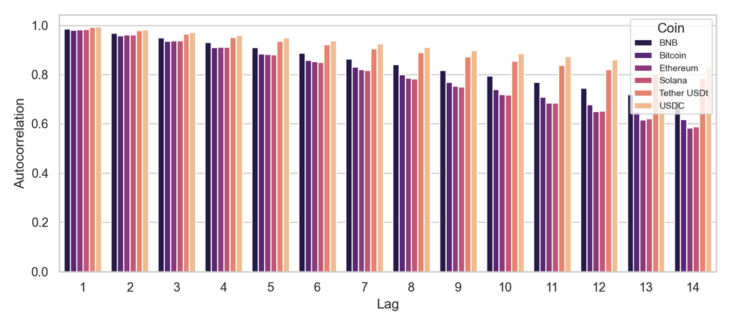

```python
crypto_acf = []
for name, group in coin_hist.groupby("name"):
    values = group["real_vol_20"].dropna().to_numpy()
    coefficients = acf(values, nlags=14, fft=True)
    crypto_acf.extend({"name": name, "lag": lag, "acf": coefficients[lag]}
                      for lag in range(1, 15))
crypto_acf = pd.DataFrame(crypto_acf)
fig, ax = plt.subplots(figsize=(9, 4))
sns.barplot(data=crypto_acf, x="lag", y="acf", hue="name", palette="magma", ax=ax)
ax.set(xlabel="Lag", ylabel="Autocorrelation")
ax.legend(title="Coin", fontsize=8)
fig.tight_layout()
plt.show()
```

Large price movements often occur close together. GARCH models allow the variance of returns to change through time.

The realized volatility is based on **past** returns. But markets (**equity** mostly) have another very cool and forward-looking indicator called the [**VIX**](https://www.cboe.com/tradable_products/vix/). The VIX is slightly different, because it is based on forward-looking option prices (taking their implied volatilities over specific horizons). Still, it is linked (empirically) to the traditional volatility.

Let’s have a look below.

**R**

```r
min_date <- "1998-01-01"                 # Starting date
max_date <- "2025-11-07"                 # Ending date
getSymbols("^VIX", src = 'yahoo',        # The data comes from Yahoo Finance
           from = min_date,              # Start date
           to = max_date,                # End date
           auto.assign = TRUE,
           warnings = FALSE)
VIX <- VIX |> as.data.frame() |>
  rownames_to_column("date") |>
  dplyr::mutate(date = as.Date(date))
head(VIX,7)                                   # Have a look at the result!
```

**Python**

```python
VIX = yf.download("^VIX", start="1998-01-01", end="2025-11-08",
                  auto_adjust=False, progress=False)
if VIX.columns.nlevels > 1:
    VIX = VIX.xs("^VIX", level=1, axis=1)
VIX = VIX.reset_index().rename(columns={"Date": "date"})
```

Both charts use the saved VIX sample, from January 1998 through November 7, 2025.

**R**

```r
VIX <- read_csv("data/4_advanced_models_vix.csv", show_col_types = FALSE)
head(VIX, 7)
```

```
# A tibble: 7 × 7
  date       `Adj Close` Close  High   Low  Open Volume
  <date>           <dbl> <dbl> <dbl> <dbl> <dbl>  <dbl>
1 1998-01-02        23.4  23.4  24.9  23.4  24.3      0
2 1998-01-05        24.4  24.4  25.0  23.0  24.1      0
3 1998-01-06        25.7  25.7  26.0  24.9  25.2      0
4 1998-01-07        25.1  25.1  27.4  25.1  26.1      0
5 1998-01-08        26.0  26.0  26.7  25.6  26.2      0
6 1998-01-09        28.7  28.7  29.4  25.7  25.8      0
7 1998-01-12        28.0  28.0  31.1  28.0  28.7      0
```

```r
vix_chart <- xts::xts(VIX$Close, order.by = VIX$date)
highchart(type = "stock") %>% hc_title(text = "Evolution of the VIX") %>%
  hc_add_series(vix_chart, name = "VIX") %>% hc_tooltip(pointFormat = "{point.y:.3f}")
```

[interactive chart not shown]

**Python**

```python
VIX = pd.read_csv("data/4_advanced_models_vix.csv", parse_dates=["date"])
print(VIX.head(7))
```

```
        date  Adj Close      Close       High        Low       Open  Volume
0 1998-01-02  23.420000  23.420000  24.930000  23.420000  24.340000       0
1 1998-01-05  24.360001  24.360001  25.020000  23.020000  24.110001       0
2 1998-01-06  25.660000  25.660000  25.969999  24.870001  25.200001       0
3 1998-01-07  25.070000  25.070000  27.430000  25.070000  26.150000       0
4 1998-01-08  26.010000  26.010000  26.700001  25.620001  26.240000       0
5 1998-01-09  28.690001  28.690001  29.350000  25.690001  25.790001       0
6 1998-01-12  28.020000  28.020000  31.080000  28.020000  28.690001       0
```

```python
fig = px.line(VIX, x="date", y="Close", title="Evolution of the VIX")
fig.update_xaxes(rangeslider_visible=True);
fig
```

[interactive chart not shown]

Periods of high volatility tend to occur together, forming **volatility clusters**.

## 2.2 Some theory

Therefore, we also need to introduce models that allow for this type of feature. In 1982, Robert Engle proposed such a model, called [**ARCH**](https://www.jstor.org/stable/1912773) for “*AutoRegressive Conditional Heteroskedasticity*”, which was generalized in 1986 to [**GARCH**](https://www.sciencedirect.com/science/article/abs/pii/0304407686900631) models. Engle obtained the Nobel Prize in economics in part for this contribution.

As we show below, GARCH models have a direct link with auto-regressive processes!

The idea is to work with the innovations, $e_t$ and to specify them a bit differently, i.e., like this: $e_t=\sigma_t z_t$, where $\sigma_t$ is going to be a changing standard deviation and $z_t$ is a simple white noise. What matters is that the vol term is modelled as
$$\sigma^2_t = a+\sum_{j=1}^pd_j\sigma^2_{t-j} + \sum_{k=1}^qb_ke^2_{t-k},$$
hence, the value of $\sigma_t^2$ depends both on its past and on the past of squared innovations.

There have been MANY extension to these models: T-GARCH, E-GARCH, etc. See for instance [GARCH models: structure, statistical inference and financial applications](https://onlinelibrary.wiley.com/doi/book/10.1002/9781119313472).

## 2.3 Examples: estimation

There are many packages for GARCH estimation. We propose two: [**ruGARCH**](https://cran.r-project.org/web/packages/rugarch/index.html) and [**fGARCH**](https://cran.r-project.org/web/packages/fGarch/index.html).

In **fGARCH**, the model is:

$$\sigma_t^2 = \omega + \alpha e_{t-1}^2 + \beta \sigma_{t-1}^2.$$
In the output, there are some additional parameters that allow to propose a more general model:

- **shape** is the shape parameter of the conditional distribution.
- **skew** is the skewness parameter of the conditional distribution.
- **delta** a numeric value, the exponent delta of the variance recursion, fixed at 2 usually.

$\delta$ values other than 2 come from P-GARCH models:

$$\begin{align}
\varepsilon_t & = \sigma_t z_t, \qquad z_t \overset{\text{i.i.d.}}{\sim} \text{Skew}(\text{shape},\text{skew}), \\
\sigma_t^{\delta}
&= \omega
+ \sum_{i=1}^{q} \alpha_i\bigl(|\varepsilon_{t-i}| - \gamma_i \varepsilon_{t-i}\bigr)^{\delta}
+ \sum_{j=1}^{p} \beta_j\,\sigma_{t-j}^{\delta},
\end{align}$$

The examples below use Gaussian innovations and a constant mean. Other distribution choices allow for skewness or heavier tails. Returns are expressed in percentage points for these fits. Python uses the [arch package](https://arch.readthedocs.io/en/latest/univariate/introduction.html), first through its model constructor, then through separate components.

**R**

```r
btc_returns <- coin_hist |> filter(name == "Bitcoin") |> pull(return) |> na.omit()
garch_returns <- 100 * btc_returns
fit_f <- garchFit(formula = ~garch(1, 1), data = garch_returns,
                   cond.dist = "norm", trace = FALSE)
fit_f
```

```
Title:
 GARCH Modelling

Call:
 garchFit(formula = ~garch(1, 1), data = garch_returns, cond.dist = "norm",
    trace = FALSE)

Mean and Variance Equation:
 data ~ garch(1, 1)
<environment: 0x321d80400>
 [data = garch_returns]

Conditional Distribution:
 norm

Coefficient(s):
     mu    omega   alpha1    beta1
0.19505  0.56730  0.10241  0.85807

Std. Errors:
 based on Hessian

Error Analysis:
        Estimate  Std. Error  t value Pr(>|t|)
mu       0.19505     0.05347    3.648 0.000265 ***
omega    0.56730     0.09049    6.269 3.63e-10 ***
alpha1   0.10241     0.01296    7.901 2.66e-15 ***
beta1    0.85807     0.01629   52.689  < 2e-16 ***
---
Signif. codes:  0 '***' 0.001 '**' 0.01 '*' 0.05 '.' 0.1 ' ' 1

Log Likelihood:
 -8533.658    normalized:  -2.622513

Description:
 Sat Nov 14 16:02:49 2026 by user:
```

**Python**

```python
btc_returns = coin_hist.loc[coin_hist["name"].eq("Bitcoin"), "return"].dropna()
garch_returns = 100 * btc_returns
fit_f = arch_model(garch_returns, mean="Constant", vol="GARCH", p=1, q=1,
                    dist="normal", rescale=False).fit(disp="off", cov_type="classic")
print(fit_f.summary())
```

```
                     Constant Mean - GARCH Model Results
==============================================================================
Dep. Variable:                 return   R-squared:                       0.000
Mean Model:             Constant Mean   Adj. R-squared:                  0.000
Vol Model:                      GARCH   Log-Likelihood:               -8531.01
Distribution:                  Normal   AIC:                           17070.0
Method:            Maximum Likelihood   BIC:                           17094.4
                                        No. Observations:                 3254
Date:                Sat, Nov 14 2026   Df Residuals:                     3253
Time:                        16:02:50   Df Model:                            1
                                Mean Model
==========================================================================
                 coef    std err          t      P>|t|    95.0% Conf. Int.
--------------------------------------------------------------------------
mu             0.1953  5.345e-02      3.655  2.574e-04 [9.058e-02,  0.300]
                             Volatility Model
==========================================================================
                 coef    std err          t      P>|t|    95.0% Conf. Int.
--------------------------------------------------------------------------
omega          0.5625  8.964e-02      6.275  3.489e-10   [  0.387,  0.738]
alpha[1]       0.1008  1.281e-02      7.869  3.562e-15 [7.570e-02,  0.126]
beta[1]        0.8595  1.615e-02     53.236      0.000   [  0.828,  0.891]
==========================================================================

Covariance estimator: classic
```

Now, with **rugarch**…

**R**

```r
spec <- ugarchspec(variance.model = list(model = "sGARCH", garchOrder = c(1, 1)),
                   mean.model = list(armaOrder = c(0, 0), include.mean = TRUE),
                   distribution.model = "norm")
garch_dates <- coin_hist |> filter(name == "Bitcoin") |> pull(date)
garch_series <- xts::xts(garch_returns, order.by = garch_dates)
fit_r <- ugarchfit(data = garch_series, spec = spec, solver = "hybrid")
fit_r@fit$coef
```

```
       mu     omega    alpha1     beta1
0.1950823 0.5671340 0.1022725 0.8581447
```

**Python**

```python
garch_components = ConstantMean(garch_returns, volatility=GARCH(p=1, q=1),
                                 distribution=Normal(), rescale=False)
fit_r = garch_components.fit(disp="off", cov_type="classic")
print(fit_r.params)
```

```
mu          0.195337
omega       0.562496
alpha[1]    0.100809
beta[1]     0.859495
Name: params, dtype: float64
```

The packages use different fitting routines, so their estimates can differ. In both R examples, the variance equation is
$$\sigma_t^2=\omega+\alpha e_{t-1}^2+\beta\sigma_{t-1}^2.$$
The coefficient $\alpha$ multiplies the squared shock; $\beta$ multiplies the previous variance.

With both libraries, it is possible to make predictions.

**R**

```r
predict(fit_f, n.ahead = 5)
```

```
  meanForecast meanError standardDeviation
1    0.1950537  2.647169          2.647169
2    0.1950537  2.701459          2.701459
3    0.1950537  2.752596          2.752596
4    0.1950537  2.800833          2.800833
5    0.1950537  2.846395          2.846395
```

```r
ugarchforecast(fit_r, n.ahead = 3)
```

```
*------------------------------------*
*       GARCH Model Forecast         *
*------------------------------------*
Model: sGARCH
Horizon: 3
Roll Steps: 0
Out of Sample: 0

0-roll forecast [T0=2025-11-29]:
    Series Sigma
T+1 0.1951 2.647
T+2 0.1951 2.701
T+3 0.1951 2.752
```

**Python**

```python
forecast_f = fit_f.forecast(horizon=5, reindex=False)
forecast_r = fit_r.forecast(horizon=3, reindex=False)
print(pd.DataFrame({"horizon": np.arange(1, 6),
                    "mean": forecast_f.mean.iloc[-1].to_numpy(),
                    "standard_deviation": np.sqrt(forecast_f.variance.iloc[-1].to_numpy())})
      .to_string(index=False))
```

```
 horizon     mean  standard_deviation
       1 0.195337            2.647828
       2 0.195337            2.700958
       3 0.195337            2.751014
       4 0.195337            2.798239
       5 0.195337            2.842852
```

```python
print(pd.DataFrame({"horizon": np.arange(1, 4),
                    "mean": forecast_r.mean.iloc[-1].to_numpy(),
                    "standard_deviation": np.sqrt(forecast_r.variance.iloc[-1].to_numpy())})
      .to_string(index=False))
```

```
 horizon     mean  standard_deviation
       1 0.195337            2.647828
       2 0.195337            2.700958
       3 0.195337            2.751014
```

The reported standard deviations are daily volatilities in percentage points.

A cool feature of `{rugarch}` is that you can use forward rolling, as in actual **backtests** (more on that below).

# 3 Vector Auto-Regression

## 3.1 The VAR(1) model

Now we are switching to full multivariate mode!  
With the **Vector Auto-Regression** (VAR). It is written as:

$$X_t = \mu + A X_{t-1} + \varepsilon_t,
\qquad \varepsilon_t \sim \text{i.i.d. } (0,\Sigma_\varepsilon),$$
with $X_t \in \mathbb{R}^k, \mu \in \mathbb{R}^k, A \in \mathbb{R}^{k \times k}$.

**NoteInterpretation**

In two dimensions: $X_t=[X_{t,1} \ X_{t,2} ]'$.

$$X_t = \mu + \begin{bmatrix} A_{11} & A_{12} \\ A_{21} & A_{22} \end{bmatrix} X_{t-1} + \text{error}$$

So $A_{11}$ measures the impact from $X_{t-1, 1}$ onto $X_{t,1}$ (itself) and same for $A_{22}$ for the second component. The non-diagonal terms drive the cross-effects: $A_{12}$ is the impact of $X_{t-1,2}$ on $X_{t,1}$ and vice-versa.

A few probabilistic properties.

**NoteMean**

If the VAR(1) is stable (all eigenvalues of $A$ satisfy $|\lambda_i(A)|<1$), the **unconditional mean** exists and is given by
$$\mathbb{E}[X_t] = (I - A)^{-1}\mu.$$

Next, let $\Gamma_0 = \mathbb{V}(X_t)$, it must satisfy
$$\Gamma_0 = A \Gamma_0 A' + \Sigma_\varepsilon.$$

Next, define the lag-$h$ autocovariance matrix:
$$\Gamma_h = \text{Cov}(X_t, X_{t-h}).$$

Using for simplicity $X_t = A X_{t-1} + \varepsilon_t$ (the constant terms do not affect the covariances):
$$\Gamma_h = \text{Cov}(A X_{t-1} + \varepsilon_t, X_{t-h}) = A \text{Cov}(X_{t-1}, X_{t-h}) + \underbrace{\text{Cov}(\varepsilon_t, X_{t-h})}_{=0}
= A \Gamma_{h-1}$$

**NoteAutocovariance**

By recursion, we obtain the multivariate version of the AR(1):
$$\Gamma_h = A^h \Gamma_0, \quad h \ge 0.$$
The correlation matrix at lag $h$ is $D^{-1/2}\Gamma_h D^{-1/2}$, where $D$ contains the variances on its diagonal.

## 3.2 The VAR(p) Model

A Vector Autoregression of order $p$, denoted VAR($p$), models a $k$-dimensional time series vector $\mathbf{X}_t = (X_{1,t}, \dots, X_{k,t})^\top$ as:

$$\mathbf{X}_t
= \mathbf{c} + A_1 \mathbf{X}_{t-1} + A_2 \mathbf{X}_{t-2} + \cdots + A_p \mathbf{X}_{t-p} + \mathbf{e}_t,$$

where:

- $\mathbf{X}_t$ is a $k \times 1$ vector of endogenous variables,
- $\mathbf{c}$ is a $k \times 1$ vector of intercept terms,
- $A_i$ are $k \times k$ coefficient matrices,
- $\mathbf{e}_t$ is a $k \times 1$ vector of innovations (reduced-form errors).

**Error term assumptions**: the innovations satisfy

$$\mathbf{e}_t \sim (0, \Sigma_e),$$

where $\Sigma_e$ is a symmetric positive definite $k \times k$ covariance matrix, allowing contemporaneous correlation across equations.

## 3.3 Empirics

VARs are often used on **macroeconomic** data. The optional download code below uses the [World Bank API](https://data.worldbank.org/).

**R**

```r
wb_raw <- WDI(                              # World Bank data
  indicator = c(
    "labor" = "SL.TLF.TOTL.IN",             # Labor force (# individuals)
    "savings_rate" = "NY.GDS.TOTL.ZS",      # Savings rate (% GDP)
    "inflation" = "FP.CPI.TOTL.ZG",         # Inflation rate
    "trade" = "NE.TRD.GNFS.ZS",             # Trade as % of GDP
    "pop" = "SP.POP.TOTL",                  # Population
    "pop_growth" = "SP.POP.GROW",           # Population growth
    "capital_formation" = "NE.GDI.TOTL.ZS", # Gross capital formation (% GDP)
    "gdp_percap" = "NY.GDP.PCAP.CD",        # GDP per capita
    "RD_percap" = "GB.XPD.RSDV.GD.ZS",      # R&D per capita
    "educ_level" = "SE.SEC.CUAT.LO.ZS",     # % pop reachiing second. educ. level
    "educ_spending" = "SE.XPD.TOTL.GD.ZS",  # Education spending (%GDP)
    "nb_researchers" = "SP.POP.SCIE.RD.P6", # Nb researchers per million inhab.
    "debt" = "GC.DOD.TOTL.GD.ZS",           # Central gov. debt (% of GDP)
    "gdp" = "NY.GDP.MKTP.CD"                # Gross Domestic Product (GDP)
  ),
  extra = TRUE,
  start = 1960,
  end = 2024) |>
  mutate(across(everything(), as.vector)) |>
  select(-status, -lending, -iso2c, -iso3c) |>
  filter(region != "Aggregates", income != "Aggregates") |>
  arrange(country, year) |>
  group_by(country) |>
  mutate(across(everything(), impute)) |>
  mutate(gdp_growth = gdp_percap/dplyr::lag(gdp_percap) - 1, .before = "region") |>
  ungroup() |>
  filter(lastupdated == max(lastupdated)) |>
  arrange(country, year)
```

**Python**

```python
indicators = {"labor": "SL.TLF.TOTL.IN", "savings_rate": "NY.GDS.TOTL.ZS",
              "inflation": "FP.CPI.TOTL.ZG", "trade": "NE.TRD.GNFS.ZS",
              "pop": "SP.POP.TOTL", "pop_growth": "SP.POP.GROW",
              "capital_formation": "NE.GDI.TOTL.ZS", "gdp_percap": "NY.GDP.PCAP.CD",
              "RD_percap": "GB.XPD.RSDV.GD.ZS", "educ_level": "SE.SEC.CUAT.LO.ZS",
              "educ_spending": "SE.XPD.TOTL.GD.ZS", "nb_researchers": "SP.POP.SCIE.RD.P6",
              "debt": "GC.DOD.TOTL.GD.ZS", "gdp": "NY.GDP.MKTP.CD"}
wb_raw = pd.DataFrame({"year": np.arange(1960, 2025)})
for name, indicator in indicators.items():
    response = requests.get(f"https://api.worldbank.org/v2/country/USA/indicator/{indicator}",
                            params={"format": "json", "date": "1960:2024", "per_page": 100},
                            timeout=120)
    response.raise_for_status()
    observations = response.json()[1]
    values = pd.DataFrame({"year": int(row["date"]), name: row["value"]}
                           for row in observations)
    wb_raw = wb_raw.merge(values, on="year", how="left")
wb_raw = wb_raw.sort_values("year")
wb_raw[list(indicators)] = wb_raw[list(indicators)].ffill(limit=6)
wb_raw["country"] = "United States"
wb_raw["gdp_growth"] = wb_raw["gdp_percap"].pct_change(fill_method=None)
```

The saved US extract comes from the original World Bank download and covers 1960 to 2024. The original preparation carries missing observations forward for at most six years. Here, `gdp_growth` measures growth in nominal GDP per capita in current US dollars.

**R**

```r
wb_raw <- read_csv("data/4_advanced_models_world_bank_us.csv", show_col_types = FALSE)
head(wb_raw |> select(country, year, gdp_growth, inflation, pop_growth))
```

```
# A tibble: 6 × 5
  country        year gdp_growth inflation pop_growth
  <chr>         <dbl>      <dbl>     <dbl>      <dbl>
1 United States  1960    NA           1.46      NA
2 United States  1961     0.0203      1.07       1.66
3 United States  1962     0.0584      1.20       1.54
4 United States  1963     0.0406      1.24       1.44
5 United States  1964     0.0592      1.28       1.39
6 United States  1965     0.0709      1.59       1.25
```

**Python**

```python
wb_raw = pd.read_csv("data/4_advanced_models_world_bank_us.csv")
print(wb_raw[["country", "year", "gdp_growth", "inflation", "pop_growth"]].head())
```

```
         country  year  gdp_growth  inflation  pop_growth
0  United States  1960         NaN   1.457976         NaN
1  United States  1961    0.020281   1.070724    1.657730
2  United States  1962    0.058402   1.198773    1.537997
3  United States  1963    0.040563   1.239669    1.439165
4  United States  1964    0.059201   1.278912    1.389046
```

Ok, let’s focus on the US for simplicity. Taking into account other countries would mean/imply a Panel VAR.  
To lighten the output (which can be heavy), we only focus on 3 variables.

**R**

```r
wb_us <- wb_raw |>
  filter(country == "United States") |>
  select(gdp_growth, inflation, pop_growth) |>
  na.omit()
fit_VAR <- VAR(wb_us, p = 1)
fit_VAR |> summary()
```

```
VAR Estimation Results:
=========================
Endogenous variables: gdp_growth, inflation, pop_growth
Deterministic variables: const
Sample size: 63
Log Likelihood: 97.776
Roots of the characteristic polynomial:
0.845  0.75 0.2559
Call:
VAR(y = wb_us, p = 1)


Estimation results for equation gdp_growth:
===========================================
gdp_growth = gdp_growth.l1 + inflation.l1 + pop_growth.l1 + const

              Estimate Std. Error t value Pr(>|t|)
gdp_growth.l1 0.422576   0.141282   2.991  0.00405 **
inflation.l1  0.001643   0.001513   1.086  0.28192
pop_growth.l1 0.004779   0.012570   0.380  0.70517
const         0.020769   0.014248   1.458  0.15025
---
Signif. codes:  0 '***' 0.001 '**' 0.01 '*' 0.05 '.' 0.1 ' ' 1


Residual standard error: 0.0253 on 59 degrees of freedom
Multiple R-Squared: 0.2914, Adjusted R-squared: 0.2554
F-statistic: 8.087 on 3 and 59 DF,  p-value: 0.0001344


Estimation results for equation inflation:
==========================================
inflation = gdp_growth.l1 + inflation.l1 + pop_growth.l1 + const

              Estimate Std. Error t value Pr(>|t|)
gdp_growth.l1 30.60299    8.81182   3.473  0.00097 ***
inflation.l1   0.56629    0.09439   6.000 1.29e-07 ***
pop_growth.l1 -0.83768    0.78398  -1.068  0.28965
const          0.84518    0.88868   0.951  0.34546
---
```

[output cut: 23 more lines]

```
F-statistic: 111.7 on 3 and 59 DF,  p-value: < 2.2e-16



Covariance matrix of residuals:
           gdp_growth inflation pop_growth
gdp_growth  0.0006403   0.01862 -0.0004703
inflation   0.0186233   2.49093 -0.0238060
pop_growth -0.0004703  -0.02381  0.0091824

Correlation matrix of residuals:
           gdp_growth inflation pop_growth
gdp_growth     1.0000    0.4663    -0.1939
inflation      0.4663    1.0000    -0.1574
pop_growth    -0.1939   -0.1574     1.0000
```

**Python**

```python
wb_us = (wb_raw.loc[wb_raw["country"].eq("United States"),
                    ["gdp_growth", "inflation", "pop_growth"]].dropna())
fit_VAR = VAR(wb_us.to_numpy()).fit(1, trend="c")
print("Equation order:", wb_us.columns.tolist())
```

```
Equation order: ['gdp_growth', 'inflation', 'pop_growth']
```

```python
print(fit_VAR.summary())
```

```
  Summary of Regression Results
==================================
Model:                         VAR
Method:                        OLS
Date:           Sat, 14, Nov, 2026
Time:                     16:02:56
--------------------------------------------------------------------
No. of Equations:         3.00000    BIC:                   -10.8285
Nobs:                     63.0000    HQIC:                  -11.0761
Log likelihood:           97.7757    FPE:                1.31886e-05
AIC:                     -11.2367    Det(Omega_mle):     1.09647e-05
--------------------------------------------------------------------
Results for equation y1
========================================================================
           coefficient       std. error           t-stat            prob
------------------------------------------------------------------------
const         0.020769         0.014248            1.458           0.145
L1.y1         0.422576         0.141282            2.991           0.003
L1.y2         0.001643         0.001513            1.086           0.277
L1.y3         0.004779         0.012570            0.380           0.704
========================================================================

Results for equation y2
========================================================================
           coefficient       std. error           t-stat            prob
------------------------------------------------------------------------
const         0.845176         0.888678            0.951           0.342
L1.y1        30.602986         8.811819            3.473           0.001
L1.y2         0.566289         0.094386            6.000           0.000
L1.y3        -0.837685         0.783982           -1.068           0.285
========================================================================

Results for equation y3
========================================================================
           coefficient       std. error           t-stat            prob
------------------------------------------------------------------------
const         0.059493         0.053956            1.103           0.270
L1.y1         0.838545         0.535011            1.567           0.117
L1.y2         0.005373         0.005731            0.938           0.348
L1.y3         0.862075         0.047600           18.111           0.000
========================================================================

Correlation matrix of residuals
            y1        y2        y3
y1    1.000000  0.466307 -0.193949
y2    0.466307  1.000000 -0.157408
y3   -0.193949 -0.157408  1.000000
```

Then, onto **forecasting**!

**R**

```r
predict(fit_VAR, n.ahead = 3)
```

```
$gdp_growth
           fcst        lower      upper         CI
[1,] 0.04827954 -0.001316983 0.09787606 0.04959652
[2,] 0.05065569 -0.004265562 0.10557695 0.05492126
[3,] 0.05195311 -0.004846277 0.10875250 0.05679939

$inflation
         fcst       lower    upper       CI
[1,] 3.000879 -0.09247298 6.094230 3.093352
[2,] 3.223890 -0.97430754 7.422087 4.198197
[3,] 3.435725 -1.34243374 8.213883 4.778159

$pop_growth
          fcst     lower    upper        CI
[1,] 0.9528018 0.7649883 1.140615 0.1878135
[2,] 0.9374872 0.6911543 1.183820 0.2463330
[3,] 0.9274756 0.6415400 1.213411 0.2859356
```

**Python**

```python
var_point, var_lower, var_upper = fit_VAR.forecast_interval(
    wb_us.to_numpy()[-fit_VAR.k_ar:], steps=3, alpha=0.05)
for column, name in enumerate(wb_us.columns):
    print(name)
    print(pd.DataFrame({"horizon": [1, 2, 3], "forecast": var_point[:, column],
                        "lower_95": var_lower[:, column], "upper_95": var_upper[:, column]})
          .to_string(index=False))
```

```
gdp_growth
 horizon  forecast  lower_95  upper_95
       1  0.048280 -0.001317  0.097876
       2  0.050656 -0.004266  0.105577
       3  0.051953 -0.004846  0.108752
inflation
 horizon  forecast  lower_95  upper_95
       1  3.000879 -0.092473  6.094230
       2  3.223890 -0.974308  7.422087
       3  3.435725 -1.342434  8.213883
pop_growth
 horizon  forecast  lower_95  upper_95
       1  0.952802  0.764988  1.140615
       2  0.937487  0.691154  1.183820
       3  0.927476  0.641540  1.213411
```

Another potential package/function is {`dynlm`}, with [documentation](https://www.jstatsoft.org/article/view/v036i12) and [tutorial for VAR](https://www.econometrics-with-r.org/16.1-vector-autoregressions.html).

# 4 A primer on prediction

## 4.1 Training/testing & co

The key idea is **backtest**: you have to put yourself in the shoes of someone living in the past. By this we mean, without knowledge of the future. To do this, you need to consider a loop that spans different dates in the past. At each point in time $t$ you:

1. extract the data available at time $t$;
2. build a predictive model;
3. make some prediction based on the currently available data;
4. evaluate the accuracy of the prediction thanks to the (future) realized values.

A simplified diagram below.

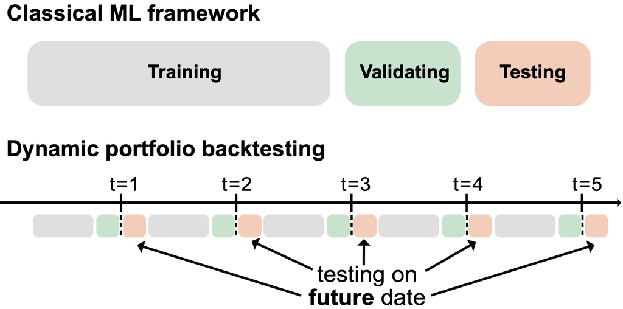

## 4.2 Some code

Even though it’s ugly, we will resort to loops.  
Below, we focus on the simple case of a unique series (bitcoin) and a simple model (ARMA), but this can be applied to much more complex situations and models.  
In the code below, we

1. build predictions;
2. derive the corresponding errors;
3. implement a trading strategy (we buy if returns are predicted to be positive and short sell otheriwse).

**R**

```r
btc <- coin_hist |>
  filter(name == "Bitcoin", lubridate::wday(date) == 2) |>
  select(date, close) |> arrange(date) |>
  mutate(end_date = lead(date), fwd_return = lead(close) / close - 1) |> drop_na()
buffer <- 100
tc <- 0.001
trading_dates <- btc$date[(buffer + 1):nrow(btc)]
period_end_dates <- btc$end_date[(buffer + 1):nrow(btc)]
pred <- err <- strat_ret <- numeric(length(trading_dates))
previous_position <- 0
for (j in seq_along(trading_dates)) {
  train <- btc |> filter(date < trading_dates[j])
  fit <- arima(train$fwd_return, order = c(1, 0, 1), include.mean = TRUE)
  pred[j] <- as.numeric(predict(fit, n.ahead = 1)$pred[1])
  realized <- btc |> filter(date == trading_dates[j]) |> pull(fwd_return)
  err[j] <- realized - pred[j]
  position <- sign(pred[j])
  strat_ret[j] <- realized * position - tc * abs(position - previous_position)
  previous_position <- position
}
strat_ret[length(strat_ret)] <- tail(strat_ret, 1) - tc * abs(previous_position)
c(forecast_weeks = length(pred))
```

```
forecast_weeks
           364
```

**Python**

```python
btc = (coin_hist.loc[coin_hist["name"].eq("Bitcoin") & coin_hist["date"].dt.weekday.eq(0),
                     ["date", "close"]].sort_values("date").copy())
btc["end_date"] = btc["date"].shift(-1)
btc["fwd_return"] = btc["close"].shift(-1) / btc["close"] - 1
btc = btc.dropna().reset_index(drop=True)
buffer = 100
tc = 0.001
trading_dates = btc["date"].iloc[buffer:].reset_index(drop=True)
period_end_dates = btc["end_date"].iloc[buffer:].reset_index(drop=True)
pred = np.empty(len(trading_dates))
err = np.empty(len(trading_dates))
strat_ret = np.empty(len(trading_dates))
previous_position = 0
for j, current_date in enumerate(trading_dates):
    train = btc.loc[btc["date"] < current_date, "fwd_return"].to_numpy()
    fit = ARIMA(train, order=(1, 0, 1), trend="c").fit()
    pred[j] = fit.forecast(steps=1)[0]
    realized = btc.loc[btc["date"].eq(current_date), "fwd_return"].iloc[0]
    err[j] = realized - pred[j]
    position = np.sign(pred[j])
    strat_ret[j] = realized * position - tc * abs(position - previous_position)
    previous_position = position
strat_ret[-1] -= tc * abs(previous_position)
print("Forecast weeks:", len(pred))
```

```
Forecast weeks: 364
```

Let’s analyze the outcome. First, the errors…

**R**

```r
sd(btc$fwd_return[(buffer + 1):nrow(btc)])
```

```
[1] 0.0895055
```

```r
sd(err)
```

```
[1] 0.09014126
```

**Python**

```python
print("Return SD on test weeks:", np.std(btc["fwd_return"].iloc[buffer:], ddof=1))
```

```
Return SD on test weeks: 0.08950550358682867
```

```python
print("Forecast error SD:", np.std(err, ddof=1))
```

```
Forecast error SD: 0.09030942511390168
```

The two standard deviations refer to the same test weeks.  
Next, onto the strategy.

**R**

```r
c(positive_net_weeks = mean(strat_ret > 0),
  mean_weekly_return = mean(strat_ret), weekly_volatility = sd(strat_ret),
  annualized_Sharpe = (mean(strat_ret) * 52 - 0.03) / (sqrt(52) * sd(strat_ret)))
```

```
positive_net_weeks mean_weekly_return  weekly_volatility  annualized_Sharpe
        0.51923077         0.01045724         0.08981237         0.79329795
```

**Python**

```python
strategy_sd = np.std(strat_ret, ddof=1)
print(pd.Series({"Positive net weeks": np.mean(strat_ret > 0),
                 "Mean weekly return": np.mean(strat_ret),
                 "Weekly volatility": strategy_sd,
                 "Annualized Sharpe": (52 * np.mean(strat_ret) - 0.03)
                                      / (np.sqrt(52) * strategy_sd)}))
```

```
Positive net weeks    0.519231
Mean weekly return    0.010457
Weekly volatility     0.089812
Annualized Sharpe     0.793298
dtype: float64
```

Let’s visualize this…

**R**

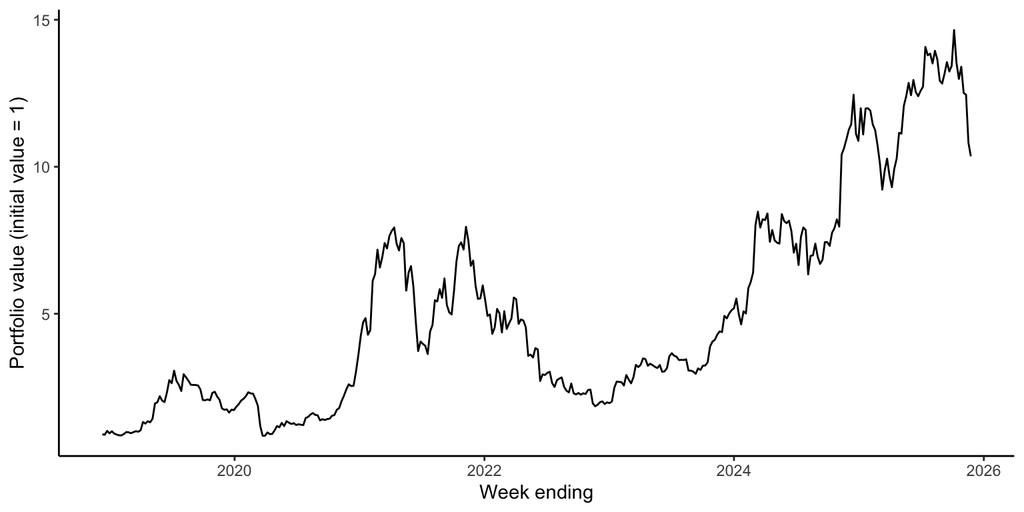

```r
tibble(date = period_end_dates, return = strat_ret) |>
  mutate(portfolio_value = cumprod(1 + return)) |>
  ggplot(aes(date, portfolio_value)) + geom_line() + theme_classic() +
  labs(x = "Week ending", y = "Portfolio value (initial value = 1)")
```

**Python**

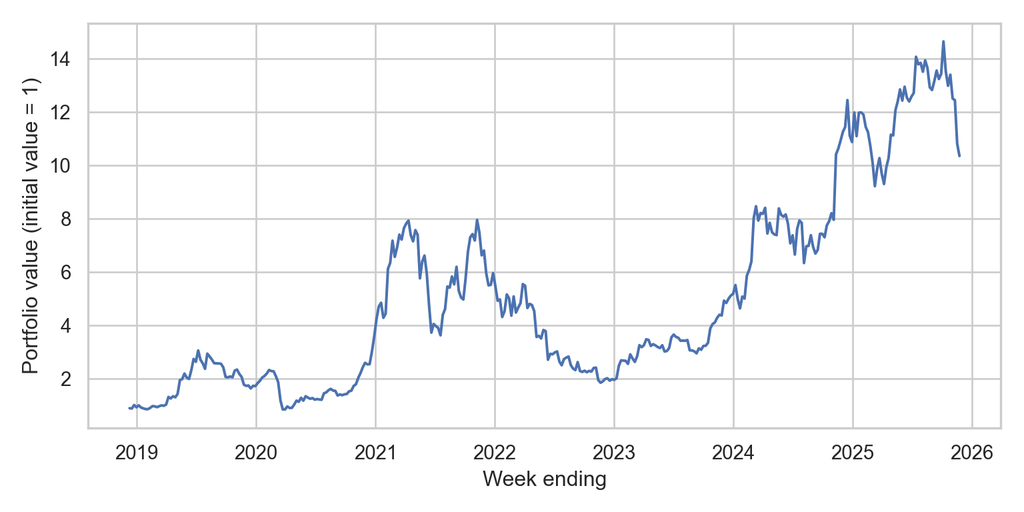

```python
portfolio_value = np.cumprod(1 + strat_ret)
fig, ax = plt.subplots(figsize=(8, 4))
ax.plot(period_end_dates, portfolio_value)
ax.set(xlabel="Week ending", ylabel="Portfolio value (initial value = 1)")
fig.tight_layout()
plt.show()
```

A position change costs 0.1% per unit of turnover, including the first entry and final exit. The portfolio value is recorded at the end of each holding week.

**NOTE**: in practice **trading costs** are super important.  
We have assumed that it’s possible to short the BTC: not so obvious, but short ETFs do exist.

## 4.3 What really matters (in finance)

Models (and people) often focus on loss (objective) functions.  
In finance, we usually try to forecast returns, hence the loss function is the (root-) **Mean Squared Error**:

$$\text{MSE} = \frac{1}{T} \sum_{t=1}^T (r_t-\tilde{r}_t)^2,$$

where $r_t$ is the realized return and $\tilde{r}_t$ is the model return. Assuming predictions are unbiased $(\mathbb{E}[r_t]=\mathbb{E}[\tilde{r}_t])$, then (after some math…)

$$\text{MSE} = \mathbb{E}[(r_t - \tilde{r}_t)^2]=\mathbb{V}[r_t]+\mathbb{V}[\tilde{r}_t]-2\text{Cov}(r_t, \tilde{r}_t)$$

**Question**: which of these terms matter the most?

- the **variance of realized returns**: nothing we can do about that.
- the **variance of predicted returns**: this enters the variace-bias tradeoff; but it’s not super clear what the impact it can have.
- the **correlation between predicted and realized returns**: this is the CRUX!!! This measures the accuracy (very similar to the hit ratio!)

# 5 Advanced temporal models

Before we can move towards chronology-based neural networks, we must explain how simple, feed-forward, NNs work.

## 5.1 (Feedforward) neural networks

A few images help explain how simple NNs work.

First, the **structure**. The network takes an input which is then processed via many multiplications, additions and activations.  
At the very end, we get the output. It can be a simple number, but could also be more complex (vector, matrix, etc.).

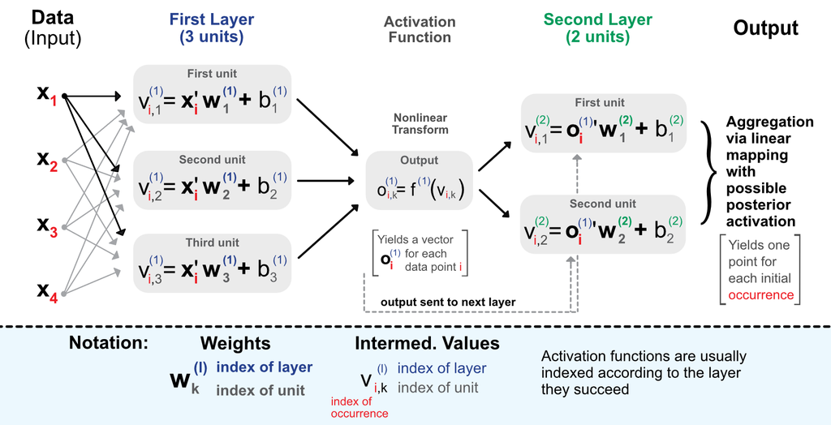

The intermediate **activation** functions are there to break the linearity. A few examples below:

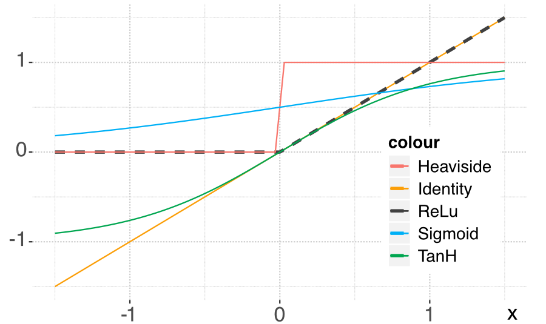

Next, the **training**. This phase is intended to determine “good” parameter values. Obviously, the “best” parameters would be ideal, but they are out of reach (the problem is too complex).

The core idea is **gradient descent**: we seek to minimize a loss function (e.g., the MSE) and this depends on the derivative:

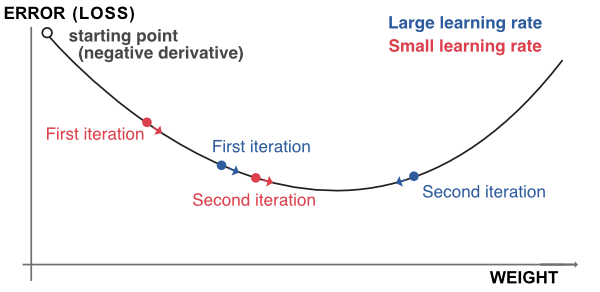

Now, there is a very interesting process called **backpropagation** that involves lots of computations of derivatives (skipped here):

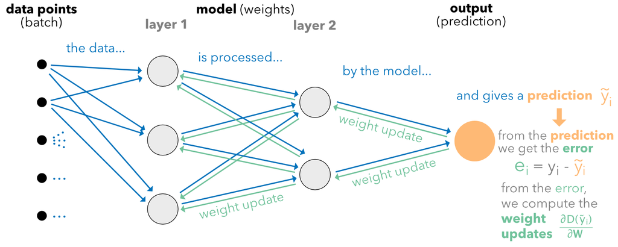

Training searches for weights that reduce the loss; it need not reach a local minimum.  
But they depend on the **training sample**: whether they work well out-of-sample (on testing sets) is another question.  
If yes, the model is said to **generalize** well. That’s the great quest of machine learning.

**Note**

An important property of NNs is that they are **universal approximators**: Any continuous function $f$ can be **approximated up to arbitrary precision** (on a finite interval) by a single layer perceptron with smooth (bounded continuous) activation function.  
This is an approximation result; it does not guarantee that training will find suitable weights.

## 5.2 Recurrent networks

Feed-forward have zero memory. How can we bring some in the model?

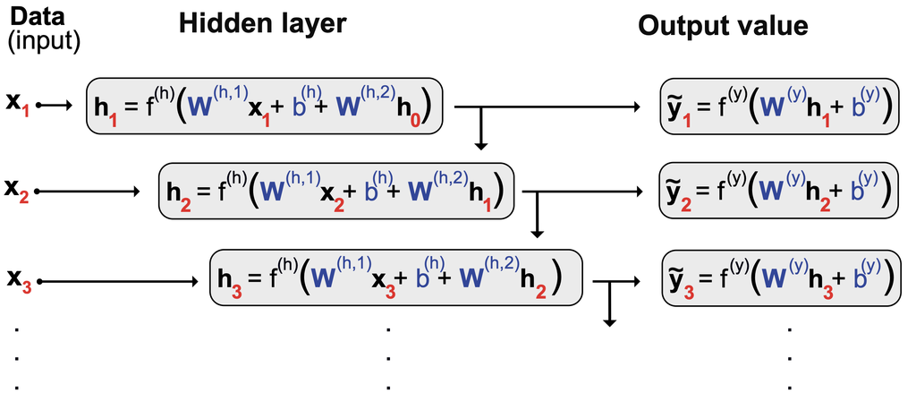

Problem: **vanishing gradients**… Hence: longer term memory! **LSTM** or **GRU**…

**NoteGated recurrent units**

The system of equations is the following
$$\begin{align*}
\tilde{y}_i&=z_i\tilde{y}_{i-1}+ (1-z_i)\tanh \left(\textbf{w}_y'\textbf{x}_i+ b_y+ u_yr_i\tilde{y}_{i-1}\right) \quad \textcolor{red}{\text{output}} \\
z_i &= \text{sig}(\textbf{w}_z'\textbf{x}_i+b_z+u_z\tilde{y}_{i-1}) \quad \textcolor{red}{\text{`update gate'}} \ \in (0,1)\\
r_i &= \text{sig}(\textbf{w}_r'\textbf{x}_i+b_r+u_r\tilde{y}_{i-1}) \quad \textcolor{red}{\text{`reset gate'}} \ \in (0,1)
\end{align*}$$

Preparing the data should follow this principle/structure

Sequence 1: [price_day1, price_day2, …, price_day10] → target: price_day11  
Sequence 2: [price_day2, price_day3, …, price_day11] → target: price_day12  
Sequence 3: [price_day3, price_day4, …, price_day12] → target: price_day13

## 5.3 Example

The optional download code fetches Nvidia prices. The worked example uses the saved sample below.

**R**

```r
getSymbols("NVDA", from = "2010-01-01", to = "2025-12-05")
prices <- Ad(NVDA)
nvda <- prices / lag(prices) - 1
nvda <- nvda[-1]
```

**Python**

```python
nvda_prices = yf.download("NVDA", start="2010-01-01", end="2025-12-05",
                          auto_adjust=False, progress=False)
if nvda_prices.columns.nlevels > 1:
    nvda_prices = nvda_prices.xs("NVDA", level=1, axis=1)
nvda_prices = nvda_prices.reset_index().rename(columns={"Date": "date"})
```

The saved sample ends on December 4, 2025. Adjusted closing prices account for stock splits and dividends.

**R**

```r
nvda_prices <- read_csv("data/4_advanced_models_nvda.csv", show_col_types = FALSE)
prices <- nvda_prices$`Adj Close`
nvda <- prices[-1] / head(prices, -1) - 1
nvda_dates <- nvda_prices$date[-1]
head(tibble(date = nvda_dates, return = nvda))
```

```
# A tibble: 6 × 2
  date         return
  <date>        <dbl>
1 2010-01-05  0.0146
2 2010-01-06  0.00640
3 2010-01-07 -0.0196
4 2010-01-08  0.00216
5 2010-01-11 -0.0140
6 2010-01-12 -0.0339
```

**Python**

```python
nvda_prices = pd.read_csv("data/4_advanced_models_nvda.csv", parse_dates=["date"])
returns = nvda_prices["Adj Close"].pct_change(fill_method=None)
nvda = returns.iloc[1:].to_numpy(dtype="float32")
nvda_dates = nvda_prices["date"].iloc[1:].reset_index(drop=True)
print(pd.DataFrame({"date": nvda_dates, "return": nvda}).head())
```

```
        date    return
0 2010-01-05  0.014602
1 2010-01-06  0.006397
2 2010-01-07 -0.019598
3 2010-01-08  0.002161
4 2010-01-11 -0.014016
```

Next, let’s prepare and format the inputs/outputs.

**R**

```r
n <- length(nvda)
look_back <- 20
X <- matrix(NA_real_, nrow = n - look_back, ncol = look_back)
y <- numeric(n - look_back)
for (i in seq_len(n - look_back)) {
  X[i, ] <- nvda[i:(i + look_back - 1)]
  y[i] <- nvda[i + look_back]
}
target_dates <- nvda_dates[(look_back + 1):n]
train_size <- floor(0.8 * nrow(X))
head(X[, 1:5])
```

```
             [,1]         [,2]         [,3]         [,4]        [,5]
[1,]  0.014602396  0.006396510 -0.019597570  0.002161203 -0.01401629
[2,]  0.006396510 -0.019597570  0.002161203 -0.014016293 -0.03389833
[3,] -0.019597570  0.002161203 -0.014016293 -0.033898333  0.01358233
[4,]  0.002161203 -0.014016293 -0.033898333  0.013582326 -0.01563392
[5,] -0.014016293 -0.033898333  0.013582326 -0.015633923 -0.02949515
[6,] -0.033898333  0.013582326 -0.015633923 -0.029495148  0.01870265
```

**Python**

```python
n = len(nvda)
look_back = 20
X = np.array([nvda[i:i + look_back] for i in range(n - look_back)], dtype="float32")
y = np.array(nvda[look_back:], dtype="float32")
target_dates = nvda_dates.iloc[look_back:].reset_index(drop=True)
train_size = int(np.floor(0.8 * len(X)))
print(X[:6, :5])
```

```
[[ 0.0146024   0.00639651 -0.01959757  0.0021612  -0.01401629]
 [ 0.00639651 -0.01959757  0.0021612  -0.01401629 -0.03389833]
 [-0.01959757  0.0021612  -0.01401629 -0.03389833  0.01358233]
 [ 0.0021612  -0.01401629 -0.03389833  0.01358233 -0.01563392]
 [-0.01401629 -0.03389833  0.01358233 -0.01563392 -0.02949515]
 [-0.03389833  0.01358233 -0.01563392 -0.02949515  0.01870264]]
```

Check the structure of features.  
Final prep: splitting & shaping

**R**

```r
X_train <- X[1:train_size, ]
y_train <- y[1:train_size]
X_test <- X[(train_size + 1):nrow(X), ]
y_test <- y[(train_size + 1):length(y)]

# Reshape for GRU [samples, timesteps, features]
X_train <- array(X_train, dim = c(nrow(X_train), ncol(X_train), 1))
X_test <- array(X_test, dim = c(nrow(X_test), ncol(X_test), 1))
```

**Python**

```python
X_train = X[:train_size, :, np.newaxis]
y_train = y[:train_size]
X_test = X[train_size:, :, np.newaxis]
y_test = y[train_size:]
print("Training shape:", X_train.shape, "Test shape:", X_test.shape)
```

```
Training shape: (3188, 20, 1) Test shape: (797, 20, 1)
```

Now: onto buidling the (simple) model.

**R**

```r
tensorflow::set_random_seed(42, disable_gpu = FALSE)
model <- keras_model_sequential() %>%
  layer_gru(units = 16, input_shape = c(look_back, 1), return_sequences = FALSE) %>%
  layer_dense(units = 1, activation = "tanh")
model %>% compile(optimizer = optimizer_adam(learning_rate = 0.001), loss = "mse")
```

**Python**

```python
keras.utils.set_random_seed(42)
model = keras.Sequential([
    keras.layers.Input(shape=(look_back, 1)),
    keras.layers.GRU(16, return_sequences=False),
    keras.layers.Dense(1, activation="tanh")])
model.compile(optimizer=keras.optimizers.Adam(learning_rate=0.001), loss="mse")
```

**Training**…

**R**

```r
fit_ <- model %>% fit(X_train, y_train, epochs = 60, batch_size = 32,
                        verbose = 0, shuffle = FALSE)
```

**Python**

```python
fit_ = model.fit(X_train, y_train, epochs=60, batch_size=32, verbose=0, shuffle=False)
```

**R**

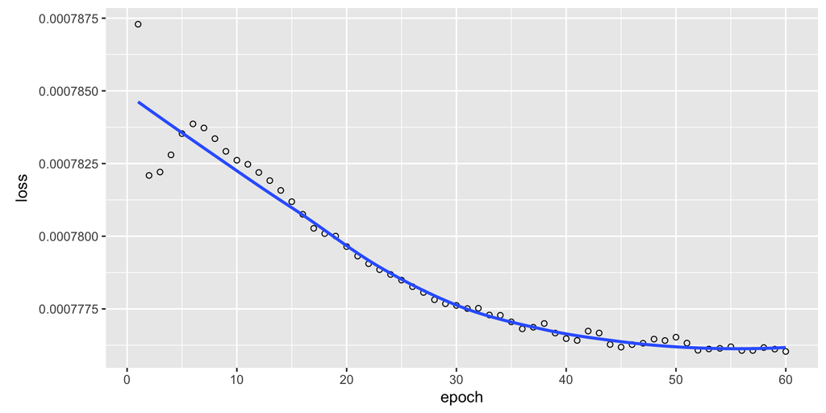

```r
plot(fit_)
```

**Python**

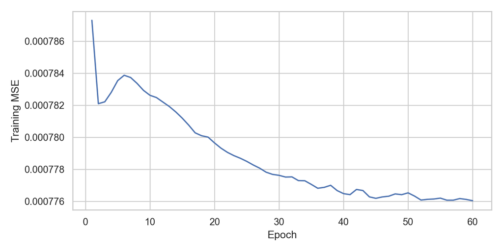

```python
fig, ax = plt.subplots(figsize=(8, 4))
ax.plot(np.arange(1, len(fit_.history["loss"]) + 1), fit_.history["loss"])
ax.set(xlabel="Epoch", ylabel="Training MSE")
fig.tight_layout()
plt.show()
```

The curve measures training error. We evaluate the forecasts on the held-out dates next.

Predict & evaluate.

**R**

```r
y_pred <- as.numeric(model %>% predict(X_test, verbose = 0))
c(MAE = mean(abs(y_test - y_pred)), hit_ratio = mean(y_test * y_pred > 0),
  correlation = cor(y_test, y_pred))
```

```
        MAE   hit_ratio correlation
 0.02325031  0.54203262  0.07687021
```

**Python**

```python
y_pred = model.predict(X_test, verbose=0).ravel()
print(pd.Series({"MAE": np.mean(np.abs(y_test - y_pred)),
                 "Hit ratio": np.mean(y_test * y_pred > 0),
                 "Correlation": np.corrcoef(y_test, y_pred)[0, 1]}))
```

```
MAE            0.023250
Hit ratio      0.542033
Correlation    0.076870
dtype: float64
```

**R**

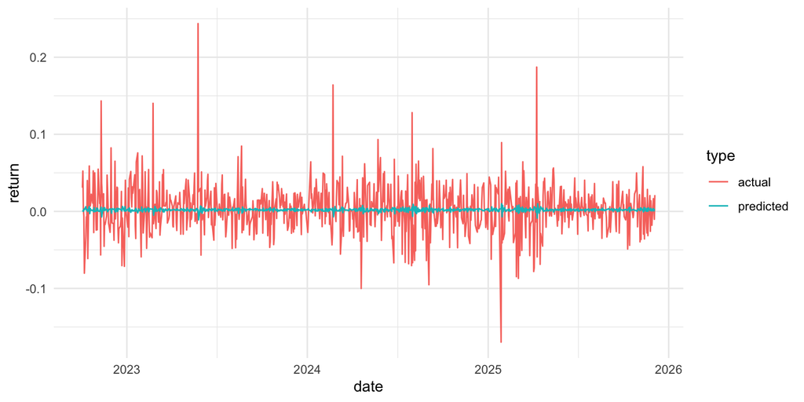

```r
tibble(date = target_dates[(train_size + 1):length(target_dates)],
       predicted = y_pred, actual = y_test) |>
  pivot_longer(-date, values_to = "return", names_to = "type") |>
  ggplot(aes(date, return, color = type)) + geom_line(linewidth = 0.5) + theme_minimal()
```

**Python**

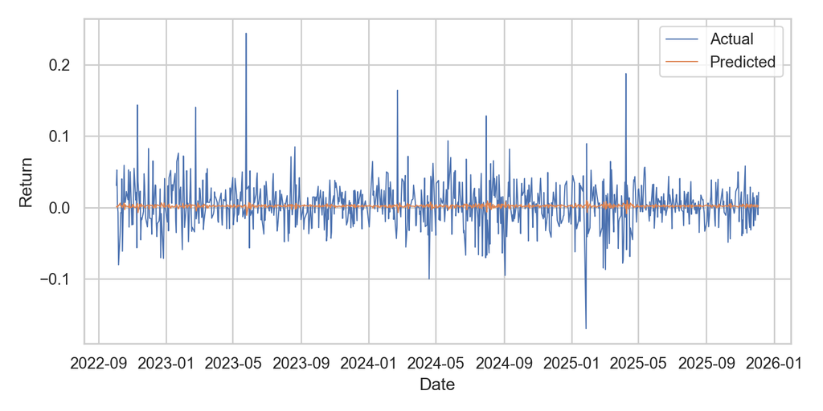

```python
fig, ax = plt.subplots(figsize=(8, 4))
ax.plot(target_dates.iloc[train_size:], y_test, label="Actual", linewidth=0.8)
ax.plot(target_dates.iloc[train_size:], y_pred, label="Predicted", linewidth=0.8)
ax.set(xlabel="Date", ylabel="Return")
ax.legend()
fig.tight_layout()
plt.show()
```

Compare the scale of the predictions with the observed returns. The correlation alone does not measure the size of the forecast errors.

## 5.4 Code for universal approximation

A first model.

**R**

```r
tensorflow::set_random_seed(42, disable_gpu = FALSE)

model_ua <- keras_model_sequential()
model_ua %>%   # This defines the structure of the network, i.e. how layers are organized
  layer_dense(units = 16, activation = 'sigmoid', input_shape = 1) %>%
  layer_dense(units = 1) #
model_ua %>% keras::compile(                      # Model specification
  loss = 'mean_squared_error',                  # Loss function
  optimizer = optimizer_rmsprop(),              # Optimisation method (weight updating)
  metrics = c('mean_absolute_error')            # Output metric
)
summary(model_ua)
```

```
Model: "sequential_2"
________________________________________________________________________________
 Layer (type)                       Output Shape                    Param #
================================================================================
 dense_3 (Dense)                    (None, 16)                      32
 dense_2 (Dense)                    (None, 1)                       17
================================================================================
Total params: 49 (196.00 Byte)
Trainable params: 49 (196.00 Byte)
Non-trainable params: 0 (0.00 Byte)
________________________________________________________________________________
```

```r
fit_ua <- model_ua %>%
  fit(seq(0, 6, by = 0.001) %>% matrix(ncol = 1),              # Training data = x
      sin(seq(0, 6, by = 0.001)) %>% matrix(ncol = 1),         # Training label = y
      verbose = 0,
      epochs = 30, batch_size = 64                             # Training parameters
  )
```

**Python**

```python
keras.utils.set_random_seed(42)
model_ua = keras.Sequential([
    keras.layers.Input(shape=(1,)),
    keras.layers.Dense(16, activation="sigmoid"),
    keras.layers.Dense(1)])
model_ua.compile(loss="mean_squared_error", optimizer=keras.optimizers.RMSprop(),
                 metrics=["mean_absolute_error"])
model_ua.summary()
```

```
Model: "sequential_3"
_________________________________________________________________
 Layer (type)                Output Shape              Param #
=================================================================
 dense_4 (Dense)             (None, 16)                32

 dense_5 (Dense)             (None, 1)                 17

=================================================================
Total params: 49 (196.00 Byte)
Trainable params: 49 (196.00 Byte)
Non-trainable params: 0 (0.00 Byte)
_________________________________________________________________
```

```python
ua_x = np.linspace(0, 6, 6001, dtype="float32").reshape(-1, 1)
fit_ua = model_ua.fit(ua_x, np.sin(ua_x), epochs=30, batch_size=64, verbose=0)
```

A second model.

**R**

```r
tensorflow::set_random_seed(42, disable_gpu = FALSE)
model_ua2 <- keras_model_sequential()
model_ua2 %>%   # This defines the structure of the network, i.e. how layers are organized
  layer_dense(units = 128, activation = 'sigmoid', input_shape = 1) %>%
  layer_dense(units = 1) #
model_ua2 %>% keras::compile(                     # Model specification
  loss = 'mean_squared_error',                  # Loss function
  optimizer = optimizer_rmsprop(),              # Optimisation method (weight updating)
  metrics = c('mean_absolute_error')            # Output metric
)
summary(model_ua2)
```

```
Model: "sequential_4"
________________________________________________________________________________
 Layer (type)                       Output Shape                    Param #
================================================================================
 dense_7 (Dense)                    (None, 128)                     256
 dense_6 (Dense)                    (None, 1)                       129
================================================================================
Total params: 385 (1.50 KB)
Trainable params: 385 (1.50 KB)
Non-trainable params: 0 (0.00 Byte)
________________________________________________________________________________
```

```r
fit_ua2 <- model_ua2 %>%
  fit(seq(0, 6, by = 0.0002) %>% matrix(ncol = 1),            # Training data = x
      sin(seq(0, 6, by = 0.0002)) %>% matrix(ncol = 1),       # Training label = y
      verbose = 0,
      epochs = 60, batch_size = 64                            # Training parameters
  )
```

**Python**

```python
keras.utils.set_random_seed(42)
model_ua2 = keras.Sequential([
    keras.layers.Input(shape=(1,)),
    keras.layers.Dense(128, activation="sigmoid"),
    keras.layers.Dense(1)])
model_ua2.compile(loss="mean_squared_error", optimizer=keras.optimizers.RMSprop(),
                  metrics=["mean_absolute_error"])
model_ua2.summary()
```

```
Model: "sequential_5"
_________________________________________________________________
 Layer (type)                Output Shape              Param #
=================================================================
 dense_8 (Dense)             (None, 128)               256

 dense_9 (Dense)             (None, 1)                 129

=================================================================
Total params: 385 (1.50 KB)
Trainable params: 385 (1.50 KB)
Non-trainable params: 0 (0.00 Byte)
_________________________________________________________________
```

```python
ua_x2 = np.linspace(0, 6, 30001, dtype="float32").reshape(-1, 1)
fit_ua2 = model_ua2.fit(ua_x2, np.sin(ua_x2), epochs=60, batch_size=64, verbose=0)
```

The comparisons.

**R**

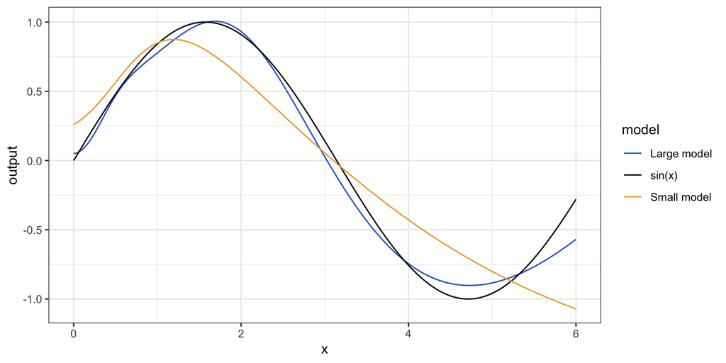

```r
ua_grid <- seq(0, 6, by = 0.001)
tibble(x = ua_grid,
       `Small model` = as.numeric(predict(model_ua, matrix(ua_grid, ncol = 1), verbose = 0)),
       `Large model` = as.numeric(predict(model_ua2, matrix(ua_grid, ncol = 1), verbose = 0)),
       `sin(x)` = sin(ua_grid)) |>
  pivot_longer(-x, names_to = "model", values_to = "output") |>
  ggplot(aes(x, output, color = model)) + geom_line() +
  scale_color_manual(values = c("Large model" = "#3366CC", "Small model" = "#EEAA33",
                                "sin(x)" = "#000000")) + theme_bw()
```

**Python**

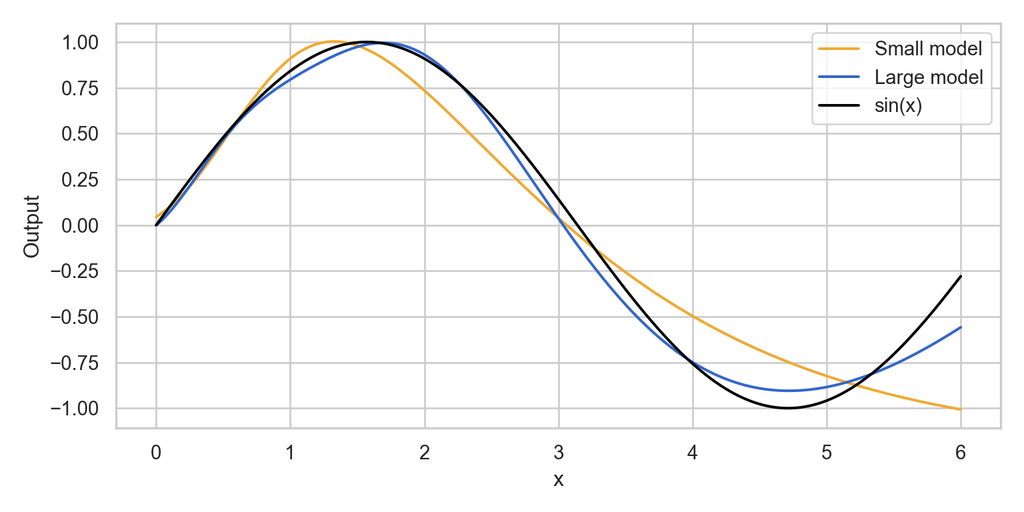

```python
ua_grid = np.linspace(0, 6, 6001, dtype="float32").reshape(-1, 1)
fig, ax = plt.subplots(figsize=(8, 4))
ax.plot(ua_grid.ravel(), model_ua.predict(ua_grid, verbose=0).ravel(),
        label="Small model", color="#EEAA33")
ax.plot(ua_grid.ravel(), model_ua2.predict(ua_grid, verbose=0).ravel(),
        label="Large model", color="#3366CC")
ax.plot(ua_grid.ravel(), np.sin(ua_grid).ravel(), label="sin(x)", color="black")
ax.set(xlabel="x", ylabel="Output")
ax.legend()
fig.tight_layout()
plt.show()
```